# Question

To generate the plot below, four parameters ($A$, $B$, $C$, and $D$) where randomly selected and plugged into the following [sinusoidal](https://en.wikipedia.org/wiki/Sine_wave) function:

$$y(t) = A\sin(Bt+C)+D$$

where
$$A>0$$
and
$$0\le C < 2 \pi$$

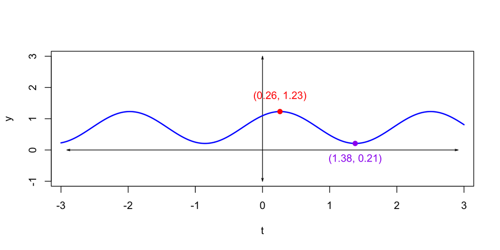

The first maximum is $(0.26, 1.23)$ and the first minimum is $(1.38, 0.21)$. Determine the values of the parameters (rounded to the nearest hundredth).

- $A =$ ##ANSWER1##
- $B =$ ##ANSWER2##
- $C =$ ##ANSWER3##
- $D =$ ##ANSWER4##

## Answerlist

- 0.42
- 0.45
- 0.48
- 0.51
- 0.54
- 2.71
- 2.74
- 2.77
- 2.80
- 2.83
- 0.78
- 0.81
- 0.84
- 0.87
- 0.90
- 0.72
- 0.75
- 0.78
- 0.81
- 0.84

# Solution

- $A = 0.51$
- $B = 2.80$
- $C = 0.84$
- $D = 0.72$

The easiest parameters to find are $A$ and $D$. With the given parameterization, $A$ is the [(semi-)amplitude](https://en.wikipedia.org/wiki/Amplitude#Semi-amplitude) and $D$ is the [vertical shift](https://en.wikipedia.org/wiki/DC_bias) of the [midline](https://www.khanacademy.org/math/algebra2/x2ec2f6f830c9fb89:trig/x2ec2f6f830c9fb89:amp-mid-period/a/midline-amplitude-and-period-review).

$$A ~=~ \frac{(1.23)-(0.21)}{2} ~=~
0.51$$

$$D ~=~ \frac{(1.23)+(0.21)}{2} ~=~
0.72$$

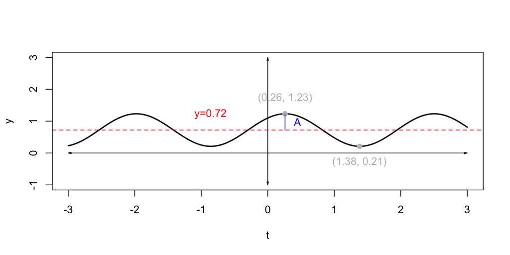

In the given parameterization, $B$ represents the [angular frequency](https://en.wikipedia.org/wiki/Angular_frequency). It is inversely proportional to the period, which is easy to determine from the 2 given points. The two marked points are half a period away from each other (in time).
$$P
~=~ 2\cdot(1.38-0.26) ~=~ 2.24$$

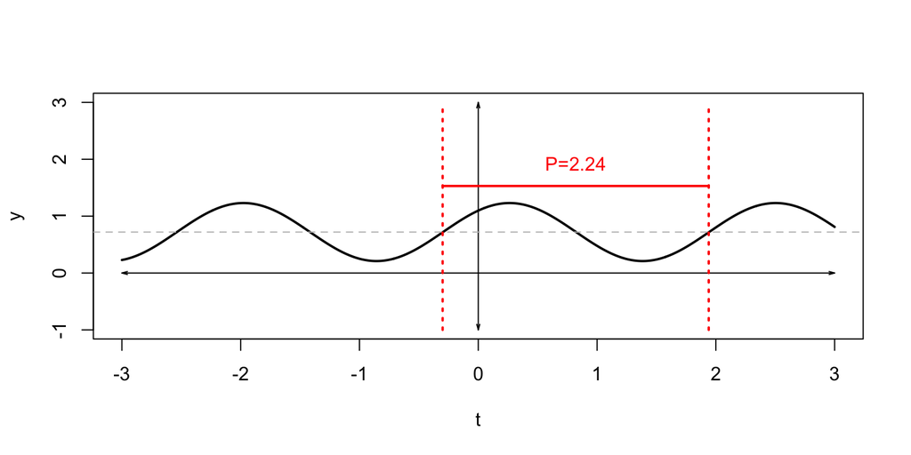

You can calculate the angular frequency by dividing $2\pi$ by the period.

$$B = \frac{2\pi}{2.24} =
2.8049934$$
We round to the hundredths place.

$$B \approx 2.8$$

With the given parameterization, $C$ represents [the phase](https://en.wikipedia.org/wiki/Sine_wave#Sinusoid_form) (in radians), representing how far into the cycle the wave is when $t=0$. It will be proportional to the horizontal shift. The horizontal shift is to the left, because a positive $C$ is added inside the argument. The parent function (sine) has a point at the origin with a positive slope. Find the analogous point (on the midline with positive slope) to the left of the vertical axis.

First, determine the quarter period is $P/4 = 0.56$. Then, recognize that the key point is 1 quarter periods before the first given point. So, to find the $t$ value of the key point:
$$0.26-1\cdot0.56 ~=~ -0.3$$
And so the key point is at $(-0.3, 0.72)$.

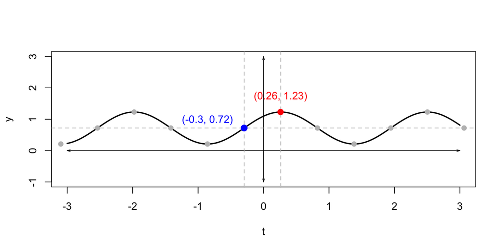

The sine function was shifted 0.3 time units to the left. If we divide 0.3 by the period and multiply by $2\pi$, it tells us the phase.

$$C = \frac{0.3}{2.24}\cdot 2\pi =
0.841498$$

Round to the nearest hundredth:

$$C \approx 0.84$$

# Meta-information

extype: cloze exclozetype: schoice|schoice|schoice|schoice exsolution: 00010|00010|00100|10000 exname: sinusoidal_params